# SR_04_RLTD_ORG_CORP_ADDR_ZIP

Related organization zip · Identifier report

## Overview

**Description**

Address Foreign - Postal code

**Table**

`SR-P04-T01-ID-RLTD-ORGS-TAXABLE-CORPORATION` (many)

**Location code**

`SCHED-R-PART-04-COL-A`

**Family**

`SCHED-R-PART-04-COL-A` · siblings: SR_04_RLTD_ORG_CORP_ADDR_CITY, SR_04_RLTD_ORG_CORP_ADDR_CNTR, SR_04_RLTD_ORG_CORP_ADDR_L1, SR_04_RLTD_ORG_CORP_ADDR_L2, SR_04_RLTD_ORG_CORP_ADDR_STATE, SR_04_RLTD_ORG_CORP_EIN

**Data type**

text (xsd: TextType, ZIPCodeType)

**Scope**

PC

**Status**

unreviewed

6

xpaths mapped (6 observed)

256,394

filings with a value

2009–2024

tax years observed

1

open flags (1 errors)

## Flags

| Severity | Flag | Xpath | Detail |
| --- | --- | --- | --- |
| ⚠ error | `COLLISION` | IRS990ScheduleR/IdRelatedOrgTxblCorpTrGrp/ForeignAddress/ForeignPostalCd | 15954 filings contain 2+ of its xpaths; most common set: /Return/ReturnData/IRS990ScheduleR/IdRelatedOrgTxblCorpTrGrp/ForeignAddress/ForeignPostalCd ; /Return/ReturnData/IRS990ScheduleR/IdRelatedOrgTx… |

## Xpaths

All mapped xpaths (under /Return/ReturnData or /Return/ReturnHeader), oldest first. Charts label each series by its xpath.

| Xpath | Form | Chart label | First year | Last year | Versions | Filings | Repeats in |
| --- | --- | --- | --- | --- | --- | --- | --- |
| IRS990ScheduleR/Form990ScheduleRPartIV/AddressUS/ZIPCode | Sched R | same | 2009 | 2012 | 17 | 40,944 | 51.8% |
| IRS990ScheduleR/Form990ScheduleRPartIV/AddressForeign/PostalCode | Sched R | …cheduleR/Form990ScheduleRPartIV/AddressForeign/PostalCode | 2009 | 2012 | 14 | 2,810 | 26.7% |
| IRS990ScheduleR/IdRelatedOrgTxblCorpTrGrp/USAddress/ZIPCode | Sched R | same | 2013 | 2013 | 3 | 14,114 | 50.3% |
| IRS990ScheduleR/IdRelatedOrgTxblCorpTrGrp/ForeignAddress/PostalCode | Sched R | …duleR/IdRelatedOrgTxblCorpTrGrp/ForeignAddress/PostalCode | 2013 | 2013 | 3 | 1,028 | 29.8% |
| IRS990ScheduleR/IdRelatedOrgTxblCorpTrGrp/USAddress/ZIPCd | Sched R | same | 2014 | 2024 | 34 | 182,343 | 51.0% |
| IRS990ScheduleR/IdRelatedOrgTxblCorpTrGrp/ForeignAddress/ForeignPostalCd | Sched R | …/IdRelatedOrgTxblCorpTrGrp/ForeignAddress/ForeignPostalCd | 2014 | 2024 | 32 | 15,155 | 43.2% |

## Coverage

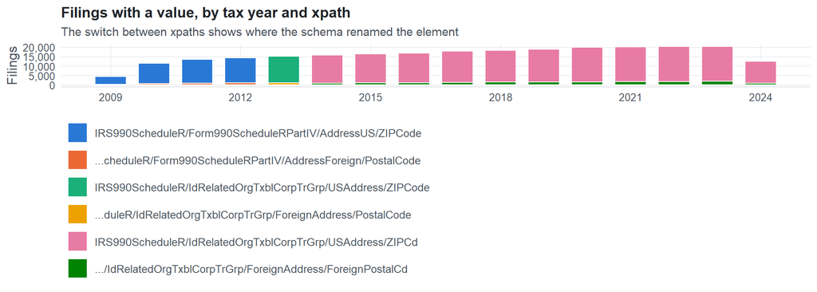

**Table view**

Table view: filings by tax year and series

| Tax year | IRS990ScheduleR/Form990ScheduleRPartIV/AddressUS/ZIPCode | …cheduleR/Form990ScheduleRPartIV/AddressForeign/PostalCode | IRS990ScheduleR/IdRelatedOrgTxblCorpTrGrp/USAddress/ZIPCode | …duleR/IdRelatedOrgTxblCorpTrGrp/ForeignAddress/PostalCode | IRS990ScheduleR/IdRelatedOrgTxblCorpTrGrp/USAddress/ZIPCd | …/IdRelatedOrgTxblCorpTrGrp/ForeignAddress/ForeignPostalCd |
| --- | --- | --- | --- | --- | --- | --- |
| 2009 | 4,167 | 261 | 0 | 0 | 0 | 0 |
| 2010 | 10,720 | 687 | 0 | 0 | 0 | 0 |
| 2011 | 12,659 | 849 | 0 | 0 | 0 | 0 |
| 2012 | 13,398 | 1,013 | 0 | 0 | 0 | 0 |
| 2013 | 0 | 0 | 14,114 | 1,028 | 0 | 0 |
| 2014 | 0 | 0 | 0 | 0 | 14,930 | 960 |
| 2015 | 0 | 0 | 0 | 0 | 15,444 | 1,009 |
| 2016 | 0 | 0 | 0 | 0 | 15,775 | 1,070 |
| 2017 | 0 | 0 | 0 | 0 | 16,561 | 1,214 |
| 2018 | 0 | 0 | 0 | 0 | 16,741 | 1,575 |
| 2019 | 0 | 0 | 0 | 0 | 17,305 | 1,507 |
| 2020 | 0 | 0 | 0 | 0 | 18,341 | 1,570 |
| 2021 | 0 | 0 | 0 | 0 | 18,550 | 1,677 |
| 2022 | 0 | 0 | 0 | 0 | 18,640 | 1,789 |
| 2023 | 0 | 0 | 0 | 0 | 18,431 | 1,830 |
| 2024 | 0 | 0 | 0 | 0 | 11,625 | 954 |

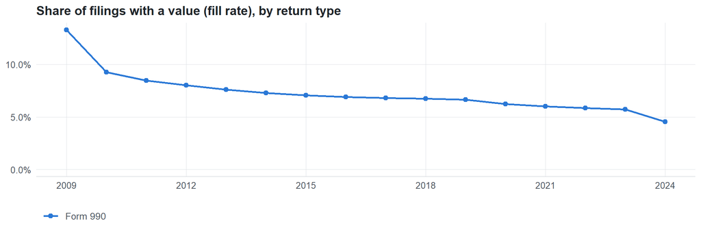

**Table view**

Table view: fill rate

| Tax year | Return type | Filings | All filings | Fill rate |
| --- | --- | --- | --- | --- |
| 2009 | Form 990 | 4,428 | 33,311 | 13.29% |
| 2010 | Form 990 | 11,407 | 123,025 | 9.27% |
| 2011 | Form 990 | 13,508 | 159,504 | 8.47% |
| 2012 | Form 990 | 14,411 | 179,688 | 8.02% |
| 2013 | Form 990 | 15,142 | 198,855 | 7.61% |
| 2014 | Form 990 | 15,890 | 218,619 | 7.27% |
| 2015 | Form 990 | 16,453 | 233,519 | 7.05% |
| 2016 | Form 990 | 16,845 | 243,903 | 6.91% |
| 2017 | Form 990 | 17,775 | 261,612 | 6.79% |
| 2018 | Form 990 | 18,316 | 271,442 | 6.75% |
| 2019 | Form 990 | 18,812 | 283,694 | 6.63% |
| 2020 | Form 990 | 19,911 | 320,342 | 6.22% |
| 2021 | Form 990 | 20,227 | 336,480 | 6.01% |
| 2022 | Form 990 | 20,429 | 349,055 | 5.85% |
| 2023 | Form 990 | 20,261 | 354,768 | 5.71% |
| 2024 | Form 990 | 12,579 | 277,298 | 4.54% |

## Repeating groups

Table cardinality in the concordance: **many**. 6 of 6 observed xpaths repeat within a filing.

Repeating element each xpath was observed in (from the raw indexed xpath)

| Xpath | Repeating element | Filings (summed over years) |
| --- | --- | --- |
| IRS990ScheduleR/Form990ScheduleRPartIV/AddressForeign/PostalCode | (none) | 179 |
| IRS990ScheduleR/Form990ScheduleRPartIV/AddressForeign/PostalCode | IRS990ScheduleR/Form990ScheduleRPartIV | 2631 |
| IRS990ScheduleR/Form990ScheduleRPartIV/AddressUS/ZIPCode | (none) | 18843 |
| IRS990ScheduleR/Form990ScheduleRPartIV/AddressUS/ZIPCode | IRS990ScheduleR/Form990ScheduleRPartIV | 22101 |
| IRS990ScheduleR/IdRelatedOrgTxblCorpTrGrp/ForeignAddress/PostalCode | (none) | 80 |
| IRS990ScheduleR/IdRelatedOrgTxblCorpTrGrp/ForeignAddress/PostalCode | IRS990ScheduleR/IdRelatedOrgTxblCorpTrGrp | 948 |
| IRS990ScheduleR/IdRelatedOrgTxblCorpTrGrp/USAddress/ZIPCode | (none) | 6705 |
| IRS990ScheduleR/IdRelatedOrgTxblCorpTrGrp/USAddress/ZIPCode | IRS990ScheduleR/IdRelatedOrgTxblCorpTrGrp | 7409 |
| IRS990ScheduleR/IdRelatedOrgTxblCorpTrGrp/ForeignAddress/ForeignPostalCd | (none) | 1425 |
| IRS990ScheduleR/IdRelatedOrgTxblCorpTrGrp/ForeignAddress/ForeignPostalCd | IRS990ScheduleR/IdRelatedOrgTxblCorpTrGrp | 13730 |
| IRS990ScheduleR/IdRelatedOrgTxblCorpTrGrp/USAddress/ZIPCd | (none) | 85289 |
| IRS990ScheduleR/IdRelatedOrgTxblCorpTrGrp/USAddress/ZIPCd | IRS990ScheduleR/IdRelatedOrgTxblCorpTrGrp | 97054 |

## Values

| Result | Check | Detail |
| --- | --- | --- |
| ▲ warn | Values have the ZIP format | 94.1% of values match ^(99999\|999999999\|99999-9999)$ |
| ✓ pass | Stored as text | data type is text |
| ✓ pass | No placeholder values | no all-zero / all-nine placeholders among the most common values |
| ⓘ info | Leading zeros present | at least 1% of values start with 0 in some year, so numeric storage would change them |

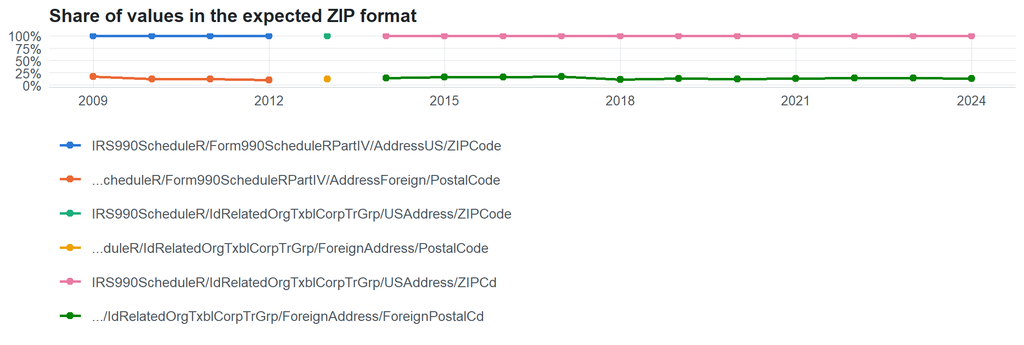

Value shapes (9 = digit, A = letter)

| Series | Shape | Expected | Filings |
| --- | --- | --- | --- |
| IRS990ScheduleR/Form990ScheduleRPartIV/AddressUS/ZIPCode | 99999 | yes | 39,053 |
| IRS990ScheduleR/Form990ScheduleRPartIV/AddressUS/ZIPCode | 999999999 | yes | 4,193 |
| …cheduleR/Form990ScheduleRPartIV/AddressForeign/PostalCode | AA9-9999 | no | 1,754 |
| …cheduleR/Form990ScheduleRPartIV/AddressForeign/PostalCode | 99999 | yes | 322 |
| …cheduleR/Form990ScheduleRPartIV/AddressForeign/PostalCode | 999999 | no | 292 |
| …cheduleR/Form990ScheduleRPartIV/AddressForeign/PostalCode | AA 99 | no | 177 |
| …cheduleR/Form990ScheduleRPartIV/AddressForeign/PostalCode | AA-9999 | no | 128 |
| …cheduleR/Form990ScheduleRPartIV/AddressForeign/PostalCode | 9999 | no | 41 |
| …cheduleR/Form990ScheduleRPartIV/AddressForeign/PostalCode | AA99 | no | 39 |
| …cheduleR/Form990ScheduleRPartIV/AddressForeign/PostalCode | 9999999999 | no | 10 |
| …cheduleR/Form990ScheduleRPartIV/AddressForeign/PostalCode | AA9A9AA | no | 10 |
| IRS990ScheduleR/IdRelatedOrgTxblCorpTrGrp/USAddress/ZIPCode | 99999 | yes | 13,508 |
| IRS990ScheduleR/IdRelatedOrgTxblCorpTrGrp/USAddress/ZIPCode | 999999999 | yes | 1,241 |
| …duleR/IdRelatedOrgTxblCorpTrGrp/ForeignAddress/PostalCode | AA9-9999 | no | 658 |
| …duleR/IdRelatedOrgTxblCorpTrGrp/ForeignAddress/PostalCode | 99999 | yes | 124 |
| …duleR/IdRelatedOrgTxblCorpTrGrp/ForeignAddress/PostalCode | 999999 | no | 114 |
| …duleR/IdRelatedOrgTxblCorpTrGrp/ForeignAddress/PostalCode | AA 99 | no | 73 |
| …duleR/IdRelatedOrgTxblCorpTrGrp/ForeignAddress/PostalCode | AA AA | no | 42 |
| IRS990ScheduleR/IdRelatedOrgTxblCorpTrGrp/USAddress/ZIPCd | 99999 | yes | 174,781 |
| IRS990ScheduleR/IdRelatedOrgTxblCorpTrGrp/USAddress/ZIPCd | 999999999 | yes | 15,609 |
| …/IdRelatedOrgTxblCorpTrGrp/ForeignAddress/ForeignPostalCd | AA9-9999 | no | 4,638 |
| …/IdRelatedOrgTxblCorpTrGrp/ForeignAddress/ForeignPostalCd | AA99999 | no | 3,590 |
| …/IdRelatedOrgTxblCorpTrGrp/ForeignAddress/ForeignPostalCd | 999999 | no | 2,121 |
| …/IdRelatedOrgTxblCorpTrGrp/ForeignAddress/ForeignPostalCd | 99999 | yes | 1,975 |
| …/IdRelatedOrgTxblCorpTrGrp/ForeignAddress/ForeignPostalCd | AA9A9AA | no | 1,505 |
| …/IdRelatedOrgTxblCorpTrGrp/ForeignAddress/ForeignPostalCd | AA 99 | no | 351 |
| …/IdRelatedOrgTxblCorpTrGrp/ForeignAddress/ForeignPostalCd | 9999 | no | 120 |

## Examples

| Tax year | Return | Xpath | Organization | Value | Source |
| --- | --- | --- | --- | --- | --- |
| 2024 | 990 | IRS990ScheduleR/IdRelatedOrgTxblCorpTrGrp/ForeignAddress/ForeignPostalCd | AVMED INC | KY1-1102 | [XML](https://gt990datalake-rawdata.s3.amazonaws.com/EfileData/XmlFiles/202533099349303308_public.xml) |
| 2024 | 990 | IRS990ScheduleR/IdRelatedOrgTxblCorpTrGrp/USAddress/ZIPCd | RISEWELL COMMUNITY SERVICES INC FKA | 11704 | [XML](https://gt990datalake-rawdata.s3.amazonaws.com/EfileData/XmlFiles/202610589349301811_public.xml) |
| 2023 | 990 | IRS990ScheduleR/IdRelatedOrgTxblCorpTrGrp/ForeignAddress/ForeignPostalCd | THE BROOKINGS INSTITUTION | 110006 | [XML](https://gt990datalake-rawdata.s3.amazonaws.com/EfileData/XmlFiles/202531349349306718_public.xml) |
| 2023 | 990 | IRS990ScheduleR/IdRelatedOrgTxblCorpTrGrp/USAddress/ZIPCd | Beattie House Inc | 03561 | [XML](https://gt990datalake-rawdata.s3.amazonaws.com/EfileData/XmlFiles/202401109349300515_public.xml) |
| 2022 | 990 | IRS990ScheduleR/IdRelatedOrgTxblCorpTrGrp/ForeignAddress/ForeignPostalCd | DUKE MEDICINE GLOBAL SUPPORT CORPORATION | 048616 | [XML](https://gt990datalake-rawdata.s3.amazonaws.com/EfileData/XmlFiles/202431359349305623_public.xml) |
| 2022 | 990 | IRS990ScheduleR/IdRelatedOrgTxblCorpTrGrp/USAddress/ZIPCd | THE GOOD SHEPHERD HOME FOR THE AGED INC | 43229 | [XML](https://gt990datalake-rawdata.s3.amazonaws.com/EfileData/XmlFiles/202401089349300430_public.xml) |
| 2021 | 990 | IRS990ScheduleR/IdRelatedOrgTxblCorpTrGrp/ForeignAddress/ForeignPostalCd | St John Providence | EC3M5DJ | [XML](https://gt990datalake-rawdata.s3.amazonaws.com/EfileData/XmlFiles/202311329349304191_public.xml) |
| 2021 | 990 | IRS990ScheduleR/IdRelatedOrgTxblCorpTrGrp/USAddress/ZIPCd | ENDOWMENT CARE AND SPECIAL CARE FUNDS OF | 94014 | [XML](https://gt990datalake-rawdata.s3.amazonaws.com/EfileData/XmlFiles/202342589349302019_public.xml) |
| 2020 | 990 | IRS990ScheduleR/IdRelatedOrgTxblCorpTrGrp/ForeignAddress/ForeignPostalCd | SENTARA HOSPITALS | KY1-1102 | [XML](https://gt990datalake-rawdata.s3.amazonaws.com/EfileData/XmlFiles/202123139349301967_public.xml) |
| 2020 | 990 | IRS990ScheduleR/IdRelatedOrgTxblCorpTrGrp/USAddress/ZIPCd | American Agents Alliance Inc | 95814 | [XML](https://gt990datalake-rawdata.s3.amazonaws.com/EfileData/XmlFiles/202102219349302160_public.xml) |
| 2019 | 990 | IRS990ScheduleR/IdRelatedOrgTxblCorpTrGrp/ForeignAddress/ForeignPostalCd | Northwestern University | KT19005 | [XML](https://gt990datalake-rawdata.s3.amazonaws.com/EfileData/XmlFiles/202141959349301014_public.xml) |
| 2019 | 990 | IRS990ScheduleR/IdRelatedOrgTxblCorpTrGrp/USAddress/ZIPCd | SOUTHFIELD NON-PROFIT HOUSING CORP | 48076 | [XML](https://gt990datalake-rawdata.s3.amazonaws.com/EfileData/XmlFiles/202013169349303486_public.xml) |

## Reviewer checklist

- The definition matches the form line and instructions for every xpath’s schema years.
- Every xpath pooled here measures the same thing on the 990 and 990-EZ (close enough for analysis).
- The coverage chart has no unexplained gaps or jumps between tax years.
- Each open flag is fixed, or accepted with a note in validation_log.csv.
- The data type is text so leading zeros and letters survive.
- The identifier belongs to the entity the variable names (the filer, preparer, related organization…).
- Formats with and without punctuation (e.g. ZIP+4, dashes) are normalized consistently downstream.

Record the review as a row in `inst/extdata/src/validation_log.csv` (variable_name, reviewer, date, status, note). Evidence built 2026-09-23 17:09:04 MST from the ef2 DuckDB builds (tax years 2009–2024).